# Charakterystyka zbioru danych

dr Magdalena Guzowska

20 września 2018

# Wymagania testów statystycznych (założenia)

Wiele procedur statystycznych m.in. korelacja, regresja, t-test, analiza wariancji wymagają, aby dane cechowały się specyficznym rozkładem, typem, czy liczebnością. Często do przeprowadzenia testów staystycznych wymagane jest, aby dane miały rozkład normalny, a wariancje grup były równe. Jeżeli test statystyczny ma takie wymagania, to należy je spełnić, aby uzyskać wiarygodne wyniki. Korelacja, test-t i ANOVA sa testami parametrycznymi, zależnymi od dystrybucji danych.

Zanim zastosuje sie testy parametryczne, niezbędne jest sprawdzenie, czy dane spełniaja założenia. W przypadku, gdy założenia nie sa spełnione, należy zastosować testy nieparametryczne.

## Ocena normalności

W przypadku **wystarczająco licznych prób** (n > 30) brak rozkładu normalego danych nie powinien stanowić dużego problemu (a na pewno nie, gdy n > 100) ze względu na centralne twierdzenie graniczne (CTG). W takiej sytuacji można zaniedbac ograniczenia dla korzystania z testów parametrycznych.Najlepiej jednak (nawet w takich przypadkach) sprawdzić, czy nasze dane maja rozkład normalny np. z zastosowaniem **testu istotności Shapiro-Wilk’a** przyrównującego dystyrybucje danych do rozkładu normalnego, w celu sprawdzenia jak bardzo nasze dane od niego się różnią.

## Ocena równości wariancji

Zarówno test *t*-Studenta (porównującego 2 niezależne próby) jak i ANOVA (porównująca więcej niż 2 próby) zakładają, że próby badane mają róne wariancje. Jeżeli próby mają rozkład normalny, to do sprawdzenia równości wariancji można wykorzystać: **test F** - do porównania wariancji 2 prób - lub testy **Bartlett’a** bądź **Lavene’a** - do porównania wariancji więcej niż 2 prób.

## Wstępne testy statystyczne - ocena dystrybucji danych

Dystrybucję danych można ocenic zarówno wizualnie (na podstawie odpowiednich wykresów), jak i po wykonaniu przeznaczonych do tego testów statystycznych.

Skorzystamy z wbudowanych danych `'ToothGrowth'`

```r
# Instalowanie wymaganych pakietów 'dplyr' i 'ggpubr'
# install.packages("dplyr") - jeżeli pakiet nie jest do tej pory zainstalowany należy użyć tej komendy
# warunkiem jest dostęp do internetu.
# if(!require(devtools)) install.packages("devtools") - niezbędny do instalacji z GitHub
# devtools::install_github("kassambara/ggpubr") - instalacja bezpośrednio z GitHub
# install.packages("ggpubr") - instalacja z CRAN

library("dplyr")
library("ggpubr")

# my_data <- read.delim(file.choose())
# Instalowanie plików tekstowych (.txt) o danych rozdzielanych tabulatorami
# my_data <- read.csv(file.choose())
# Instalowanie plików tekstowych (.csv) o danych rozdzielanych przecinkami

dane <- ToothGrowth # tworzymy ramkę danych 'dane'

head(dane) # Funkcja R pokazująca (standardowo) górnych 5 rzędów danych
```

|  | len | supp | dose |
| --- | --- | --- | --- |
| 1 | 4.2 | VC | 0.5 |
| 2 | 11.5 | VC | 0.5 |
| 3 | 7.3 | VC | 0.5 |
| 4 | 5.8 | VC | 0.5 |
| 5 | 6.4 | VC | 0.5 |
| 6 | 10.0 | VC | 0.5 |

```r
# funkcja tail() pokazuje ostatnie 5

# 'sample_n()' z pakietu 'dplyr'
# w połączeniu z funkcją 'set.seed' wypisze n (tu: n = 10) losowych rzędów

set.seed(1234)
dplyr::sample_n(dane, 10)
```

|  | len | supp | dose |
| --- | --- | --- | --- |
| 7 | 11.2 | VC | 0.5 |
| 37 | 8.2 | OJ | 0.5 |
| 36 | 10.0 | OJ | 0.5 |
| 58 | 27.3 | OJ | 2.0 |
| 49 | 14.5 | OJ | 1.0 |
| 57 | 26.4 | OJ | 2.0 |
| 1 | 4.2 | VC | 0.5 |
| 13 | 15.2 | VC | 1.0 |
| 35 | 14.5 | OJ | 0.5 |
| 27 | 26.7 | VC | 2.0 |

## Ocena normalności dystrybucji danych

Chcemy wiedzieć czy zmienna ‘len’ (długość zębów) ma rozkład normalny. Duża próba (n > 30) powinna na zasadzie CTG mieć rozkład zbliżony do rozkładu normalnego. Jednakże, często zakłada się, że gwarancję daje próba liczniejsz od 100 lub nawet 120. Najlepiej jest, zatem, sprawdzić dystrybucję danych.

### Metody wizualne - **wykres gęstości** i **wykres kwantylowy** (*ang. Quantile to Quantile plot; Q-Q plot*)

Wykres gęstości pozwala stwierdzić, czy rozkład danych ma kształt dzwonowy.

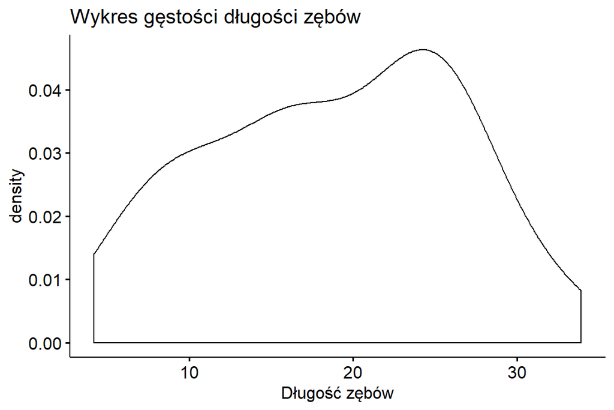

```r
library("ggpubr")
ggdensity(dane$len,
          main = "Wykres gęstości długości zębów",
          xlab = "Długość zębów")
```

Wykres kwantylowy obrazuje korelację pomiędzy próbą doświadczalną a warściami rozkładu normalnego.

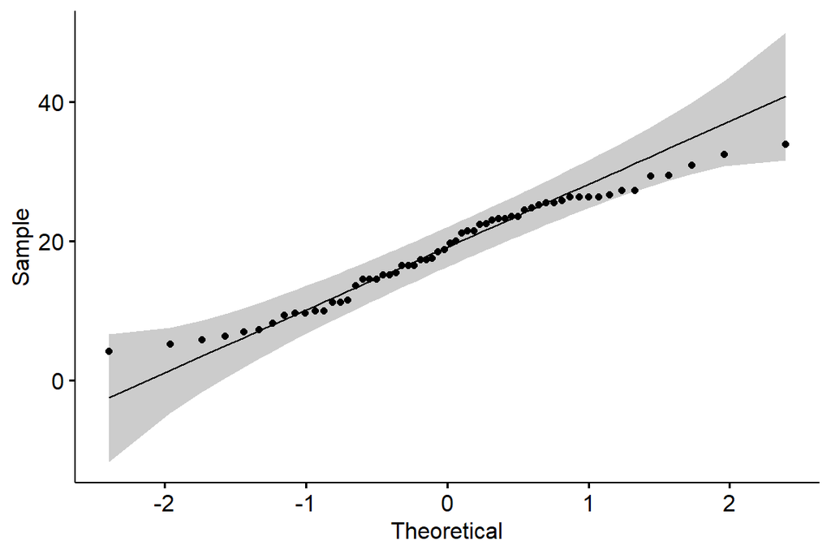

```r
ggqqplot(dane$len)
```

Jeśli wszystkie punkty układają się wzdłuż linii referencyjnej, możemy założyć normalność dystrybucji próby.

Podobny wynik uzyskamy korzystając z funkcji `qqPlot()` znajdującej się w pakiecie `'car'`

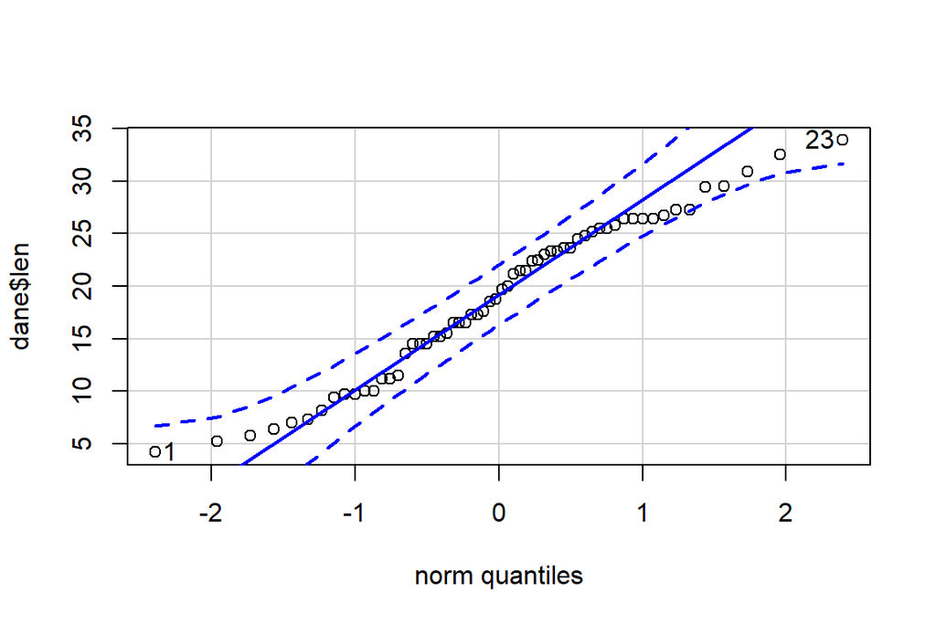

```
[1] 23  1
```

```r
library("car")
qqPlot(dane$len)
```

### Testy istotności

Zwykle nie można polegać jedynie na inspekcji wizualnej (może mieć głównie zanzczenie pomocnicze). Bardziej wiarygodne wyniki na temat dystrybucji próby dadzą testy istotności, porównujęce rozkład badanej próby do rozkładu normalnego. Nejczęściej wykorzstywane są **test normalności Kolmogorov-Smirnov’a (K-S)** i **test Shapiro-Wilk’a**. Hipotezą zerową (H<sub>0</sub>) dla tych testów jest założenie, że próba ma rozkład normalny. Jeżeli uzyskamy wynik statystyki testowej mieszczący się w obszarze krytycznym (wynik istotny statystycznie) odrzucamy hipotezę o normalności rozkładu. Test Shapiro-Wilk’a ma większą moc od testu K-S i jest rekomendowany do badania rozkładu próby. Testy istotności są zależne od wielkości próby. Zwykle małe próby “zdają” test normalności. Szczególnie w takich przypadkach istotne jest dokananie oceny statystycznej i wizualnej próby.

```r
shapiro.test(dane$len)
```

```
    Shapiro-Wilk normality test

data:  dane$len
W = 0.96743, p-value = 0.1091
```

Na podstawie uzyskanej statystyki (W) i *p-Value*, nie mamy podstaw do odrzucenia H<sub>0</sub> i możemy uznać, że nasze dane mają rozkład normalny.